# Galls report

Víctor Granda

6 de agosto de 2015

# Carga de datos

En primer lugar cargamos los datos y las librerías necesarias para realizar el análisis.

```r
#### Cargamos las librerías necesarias
library(magrittr) # para los pipes
library(dplyr) # para las modificaciones de datos
library(tidyr) # para las modificaciones de datos
library(ggplot2) # para las gráficas
library(readr) # para la carga de datos
library(pixiedust) # para mostrar las tablas de datos
library(DT) # para mostrar las tablas de datos
library(d3heatmap) # heatmap
library(viridis) # colores para daltónicos
library(extrafont) # fuentes extras para las gráficas
library(purrr) # para el t.test simultaneo
library(broom) # para crear los df con los resultados de los t.test
# Load fonts
loadfonts()


#### Cargamos los datos

data_pgrs <- read_csv2('Data/pgrs_foliolos_vs_agallas.csv')

data_dictionary <- read_csv2('Data/data_dictionary.csv')
```

## Transformaciones de los datos para el análisis

### *Long* a *Wide*

En este caso, para facilitar el análisis lo primero que vamos a hacer es pasar los datos del formato *long* al formato *wide*. Esto quiere decir que en vez de tener una sola variable (cantidad o concentración) vamos a tener una variable para cada hormona.

```r
# Datos de cantidad
data_pgrs_cantidad <- data_pgrs %>%
  select(-Concentración) %>%
  spread(Compuesto, Cantidad)

# Datos de concentración
data_pgrs_conc <- data_pgrs %>%
  select(-Cantidad) %>%
  spread(Compuesto, Concentración)
```

### Eliminar pseudoréplicas

Las réplicas analíticas debemos colapsarlas a medias, ya que si no lo hiciesemos nuestro *n* sería 15 (5 * 3), y serían pseudoréplicas.

```r
# cantidad
data_pgrs_cantidad %<>%
  group_by(ID) %>%
  summarise_each(funs(mean(., na.rm = TRUE))) %>%
  select(-RA) # elimino la columna de réplica analítica, ya no es necesaria

# concentración
data_pgrs_conc %<>%
  group_by(ID) %>%
  summarise_each(funs(mean(., na.rm = TRUE))) %>%
  select(-RA) # elimino la columna de réplica analítica, ya no es necesaria
```

### Añadir árbol

Necesitamos saber de que árbol es cada muestra, ya que para el análisis es necesario tener en cuenta el árbol de procedencia. Esto se debe a que los niveles hormonales en la agalla no son independientes de los niveles hormonales en el hemifoliolo no afectado, pues proceden del mismo individuo.

```r
# cantidad
data_pgrs_cantidad %<>%
  separate(ID, c('ID', 'árbol'), sep = '-')

# concentración
data_pgrs_conc %<>%
  separate(ID, c('ID', 'árbol'), sep = '-')
```

### Eliminar reguladores

Desgraciadamente, en la Giberelina 3 (`GA3`), para los datos de agallas tenemos dos individuos, mientras que para los testigos solo uno. No sería muy útil analizar esta hormona, y en el caso de hacer análisis multivariantes nos podría afectar negativamente alterando los resultados. Así que tenemos que eliminar este regulador.

```r
# cantidad
data_pgrs_cantidad %<>%
  select(-GA3)

# concentración
data_pgrs_conc %<>%
  select(-GA3)
```

## Datos limpios

Finalmente, tras todo este proceso obtenemos los datos “*limpios*”. Comprobamos que estén bien, primero los datos de cantidad:

| ID | árbol | ABA | BA | BK | DHZ | GA9 | IAA | IP | IPA | JA | RDHZ | SA | Z |
| --- | --- | --- | --- | --- | --- | --- | --- | --- | --- | --- | --- | --- | --- |
| Ff | 1 | 67.715 | 1.028 | 1036.6 | 0.592 | 3.676 | 5.688 | 6.07 | 29.681 | 1.696 | 13.176 | 34.424 | 0.22 |
| Ff | 2 | 55.101 | 0.372 | 650.1 | 0.174 | 3.402 | 4.209 | 7.571 | 14.604 | 0.656 | 12.934 | 19.143 | 0.11 |
| Ff | 3 | 65.035 | 0.424 | 1574.1 | 0.428 | 4.324 | 5.095 | 5.102 | 19.563 | 0.618 | 12.558 | 26.275 | 0.074 |
| Ff | 4 | 18.574 | 0.334 | 712.8 | 0.402 | 1.603 | 9.665 | 6.921 | 26.674 | 1.038 | 13.237 | 30.823 | 0.048 |
| Ff | 5 | 51.873 | 0.277 | 1691.4 | 0.215 | 1.441 | 4.576 | 11.69 | 15.845 | 1.363 | 13.055 | 28.91 | 0.135 |
| T1 | 1 | 236.843 | 0.499 | 6247.1 | 0.167 | 5.037 | 2.635 | 0.382 | 0.926 | 1.456 | 13.173 | 76.759 | 0.175 |
| T1 | 2 | 119.89 | 0.883 | 6845.9 | 0.178 | 4.682 | 2.685 | 0.552 | 1.925 | 1.264 | 13.125 | 87.541 | 0.207 |
| T1 | 3 | 98.831 | 1.997 | 8770.9 | 0.505 | 6.771 | 3.872 | 0.983 | 1.99 | 4.169 | 13.5 | 71.374 | 0.518 |
| T1 | 4 | 52.281 | 0.339 | 4588.5 | 0.18 | 1.334 | 2.739 | 0.491 | 2.007 | 1.551 | 13.368 | 66.875 | 0.175 |
| T1 | 5 | 77.865 | 0.486 | 6155.4 | 0.192 | NaN | 1.719 | 0.5 | 0.684 | 1.945 | 12.947 | 61.443 | 0.178 |

Y luego los datos de concentración:

| ID | árbol | ABA | BA | BK | DHZ | GA9 | IAA | IP | IPA | JA | RDHZ | SA | Z |
| --- | --- | --- | --- | --- | --- | --- | --- | --- | --- | --- | --- | --- | --- |
| Ff | 1 | 94.439 | 1.434 | 1445.7 | 0.825 | 5.127 | 7.932 | 8.466 | 41.395 | 2.365 | 18.376 | 48.01 | 0.307 |
| Ff | 2 | 76.333 | 0.515 | 900.7 | 0.242 | 4.713 | 5.83 | 10.489 | 20.231 | 0.908 | 17.918 | 26.519 | 0.152 |
| Ff | 3 | 91.309 | 0.596 | 2210 | 0.602 | 6.071 | 7.153 | 7.163 | 27.467 | 0.867 | 17.632 | 36.889 | 0.104 |
| Ff | 4 | 24.791 | 0.446 | 951.3 | 0.537 | 2.14 | 12.899 | 9.237 | 35.601 | 1.385 | 17.667 | 41.139 | 0.064 |
| Ff | 5 | 70.236 | 0.376 | 2290.1 | 0.291 | 1.951 | 6.196 | 15.828 | 21.454 | 1.845 | 17.677 | 39.144 | 0.183 |
| T1 | 1 | 321.475 | 0.677 | 8479.4 | 0.226 | 6.837 | 3.576 | 0.519 | 1.257 | 1.976 | 17.88 | 104.188 | 0.238 |
| T1 | 2 | 162.891 | 1.2 | 9301.3 | 0.241 | 6.361 | 3.648 | 0.75 | 2.616 | 1.718 | 17.832 | 118.939 | 0.281 |
| T1 | 3 | 135.596 | 2.739 | 12033.7 | 0.692 | 9.29 | 5.313 | 1.348 | 2.731 | 5.719 | 18.522 | 97.926 | 0.71 |
| T1 | 4 | 70.3 | 0.456 | 6170 | 0.242 | 1.794 | 3.683 | 0.66 | 2.698 | 2.085 | 17.976 | 89.924 | 0.235 |
| T1 | 5 | 107.713 | 0.673 | 8515 | 0.266 | NaN | 2.378 | 0.692 | 0.947 | 2.69 | 17.91 | 84.996 | 0.246 |

# Estadística descriptiva

Vamos a ver un poco la estructura de los datos y los primeros resultados preliminares, mediante análisis y gráficas descriptivas.

## Gráficas de cajas (*boxplots*)

Vamos a ver la distribución de cada uno de los estados (agalla y testigo) para cada hormona, para visualizar las posibles diferencias:

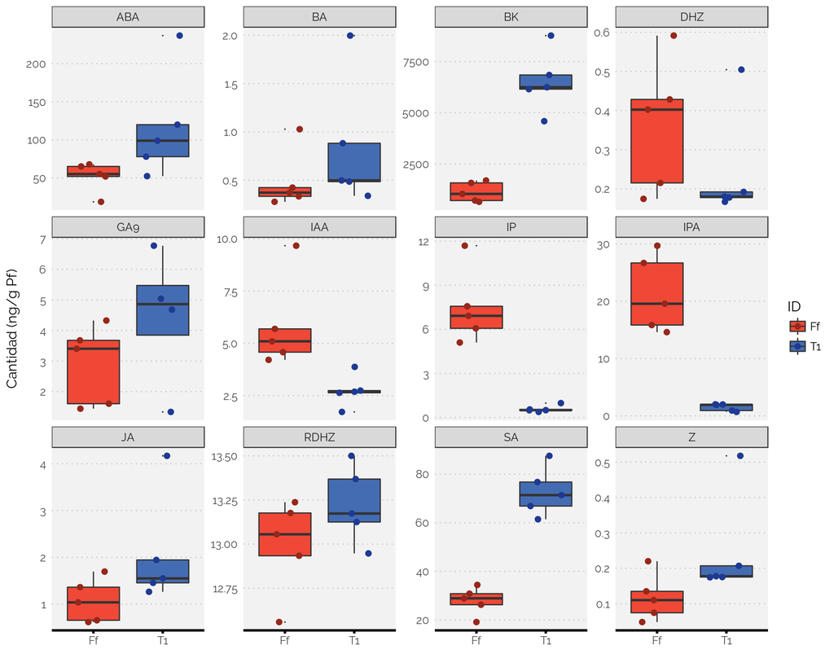

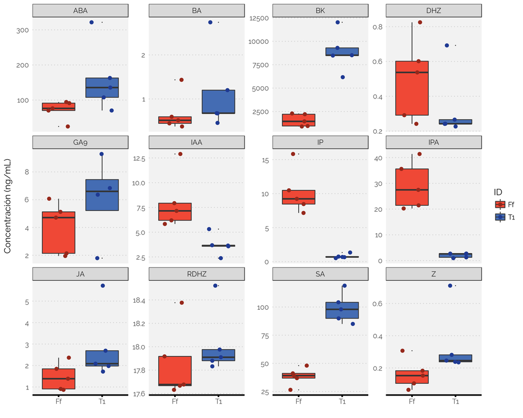

La verdad es que tiene buena pinta. A simple vista tenemos dos grupos de reguladores:

1. `ABA`, `BA`, `BK`, `GA9`, `JA`, `RDHZ`, `SA` y `Z`, que disminuyen su contenido en agallas en comparación con los testigos.
2. `DHZ`, `IAA`, `IP` e `IPA`, que aumentan su contenido en agallas en comparación con los testigos.

### Visualización de outliers

Vamos a intentar identificar los puntos correspondientes a cada árbol, para comprobar que los outliers visualizados en las gráficas de cajas corresponden al mismo árbol en todas las hormonas o si en cada una es uno diferente. Esto es importante, porque si es el mismo árbol deberíamos eliminarlo, ya que nos alteraría los análisis. Para ello, simplemente repito la gráfica anterior, pero en este caso numero los puntos por el número de arbol al que pertenecen:

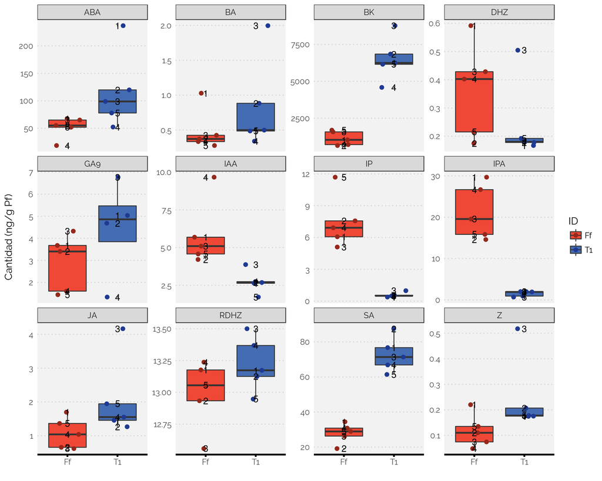

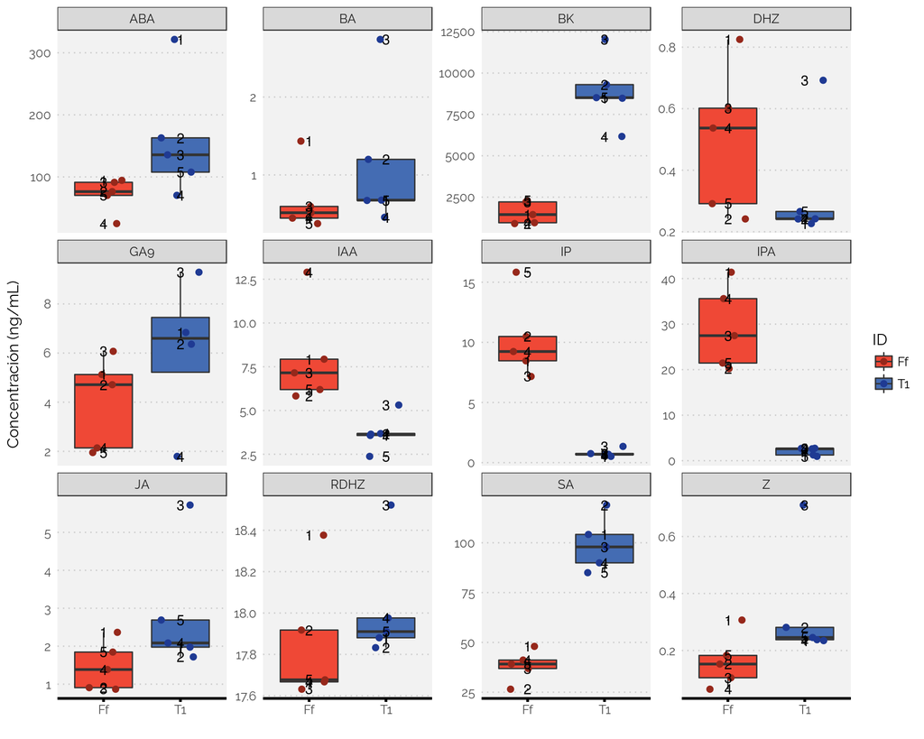

```r
data_pgrs_conc_or <- data_pgrs_conc %>%
  filter(árbol != '3')
data_pgrs_conc_or[4,7] <- NaN

data_pgrs_cantidad_or <- data_pgrs_cantidad %>%
  filter(árbol != '3')
data_pgrs_cantidad_or[4,7] <- NaN
```

Una vez eliminados los outliers, rehago los diagramas de cajas para ver como quedan:

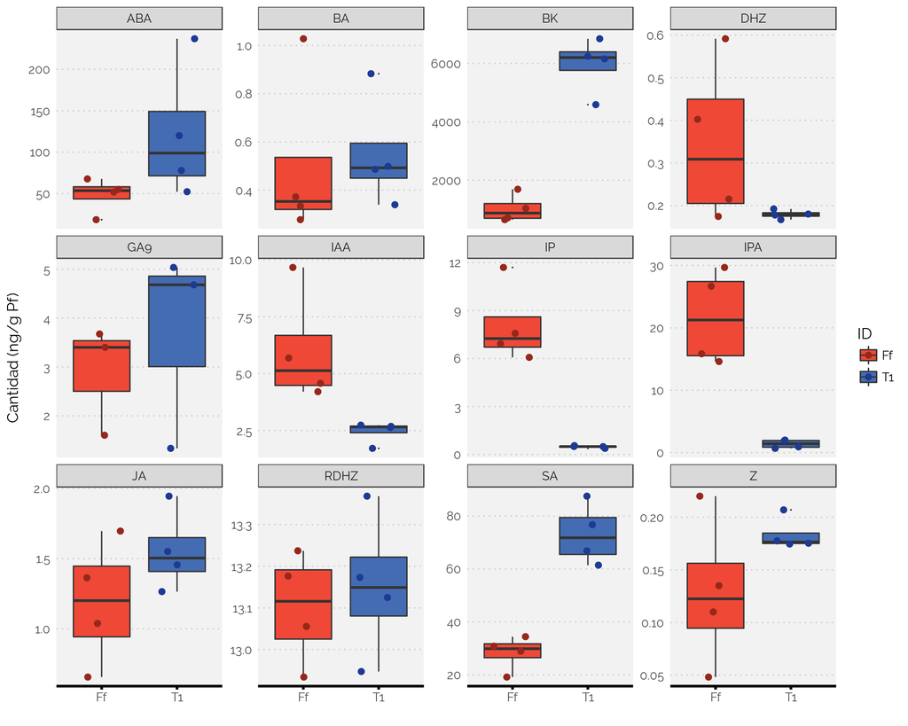

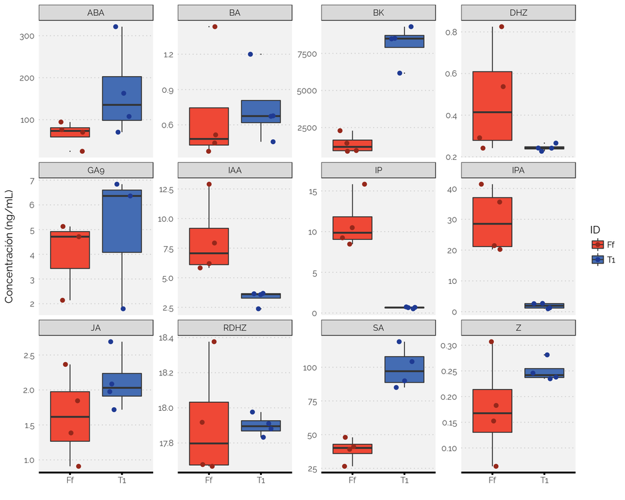

Con los datos limpios de outliers tenemos tres grupos:

1. `ABA`, `BK`, `JA`, `SA` y `Z`, que disminuyen su contenido en agallas en comparación con los testigos.
2. `DHZ`, `IAA`, `IP` e `IPA`, que aumentan su contenido en agallas en comparación con los testigos.
3. `BA`, `GA9` y `RDHZ`, que no parecen modificar su contenido o concentración en agallas y testigos.

## *Paired t test*

Como cada par de muestras, `agalla` y `testigo`, proceden del mismo árbol, las muestras de cada grupo **no** son independientes. Esto supondría un problema si comparásemos las medias de cada grupo sin tenerlo en cuenta. La solución más sencilla es realizar un contraste de medias mediante un *t test*, pero considerando cada par de muestras `agalla` y `testigo` del mismo árbol como emparejadas.  
Las siguientes tablas muestran los resultados de los *t test* para cada hormona, primero con los datos de cantidad:

| Hormona | estimate | t | p.value | df | conf.low | conf.high |
| --- | --- | --- | --- | --- | --- | --- |
| ABA | -73.404 | -2.225 | 0.113 | 3 | -178.397 | 31.589 |
| BA | -0.049 | -0.224 | 0.837 | 3 | -0.746 | 0.648 |
| BK | -4936.525 | -9.858 | 0.002 | 3 | -6530.225 | -3342.825 |
| DHZ | 0.167 | 1.672 | 0.193 | 3 | -0.151 | 0.484 |
| GA9 | -0.791 | -1.491 | 0.274 | 2 | -3.073 | 1.491 |
| IAA | 3.59 | 3.088 | 0.054 | 3 | -0.11 | 7.29 |
| IP | 7.582 | 6.148 | 0.009 | 3 | 3.657 | 11.506 |
| IPA | 20.315 | 5.319 | 0.013 | 3 | 8.16 | 32.471 |
| JA | -0.366 | -1.802 | 0.169 | 3 | -1.012 | 0.28 |
| RDHZ | -0.053 | -0.784 | 0.49 | 3 | -0.267 | 0.161 |

[output cut: 2 more lines]

Y con los de concentración:

| Hormona | estimate | t | p.value | df | conf.low | conf.high | method | alternative |
| --- | --- | --- | --- | --- | --- | --- | --- | --- |
| ABA | -99.145 | -2.255 | 0.109 | 3 | -239.059 | 40.769 | Paired t-test | two.sided |
| BA | -0.059 | -0.193 | 0.86 | 3 | -1.03 | 0.912 | Paired t-test | two.sided |
| BK | -6719.495 | -9.996 | 0.002 | 3 | -8858.723 | -4580.267 | Paired t-test | two.sided |
| DHZ | 0.23 | 1.643 | 0.199 | 3 | -0.215 | 0.675 | Paired t-test | two.sided |
| GA9 | -1.005 | -1.488 | 0.275 | 2 | -3.91 | 1.901 | Paired t-test | two.sided |
| IAA | 4.893 | 3.234 | 0.048 | 3 | 0.077 | 9.709 | Paired t-test | two.sided |
| IP | 10.35 | 6.318 | 0.008 | 3 | 5.137 | 15.563 | Paired t-test | two.sided |
| IPA | 27.791 | 5.258 | 0.013 | 3 | 10.971 | 44.61 | Paired t-test | two.sided |
| JA | -0.491 | -1.664 | 0.195 | 3 | -1.431 | 0.448 | Paired t-test | two.sided |
| RDHZ | 0.01 | 0.053 | 0.961 | 3 | -0.573 | 0.593 | Paired t-test | two.sided |

[output cut: 2 more lines]

Los resultados de los tests se resumen en la siguiente tabla:

| Regulador | Significativo_Cantidad | Significativo_Concentracion |
| --- | --- | --- |
| ABA | No | No |
| BA | No | No |
| BK | Sí | Sí |
| DHZ | No | No |
| GA9 | No | No |
| IAA | No | Sí |
| IP | Sí | Sí |
| IPA | Sí | Sí |
| JA | No | No |
| RDHZ | No | No |

[output cut: 2 more lines]

Como podemos observar, exiten diferencias significativas para 4 o 5 hormonas, según miremos cantidad o concentración. Visto esto, a partir de aquí voy a trabajar con los datos de concentración, ya que nos incluye el `IAA` entre las hormonas significativamente alteradas en el proceso.

En cuanto a las hormonas significativas, observamos dos grupos:

- `BK` y `SA`, que disminuyen su contenido en la agalla en comparación con el testigo.
- `IAA`, `IP` e `IPA`, que aumentan su contenido en la agalla en comparación con el testigo.

Estas parecen las hormonas más importantes de las estudiadas en el proceso de formación o establecimiento de la agalla. Aún así vamos a hacer un análisis de clúster, para comprobar que esto es así, y además ver como el resto de reguladores se agrupan, ya que aunque no den diferencias significativas, su acción en conjunto también puede ser determinante.

## *Cluster analysis*

```r
d3heatmap(data_pgrs_conc_or_heatmap, scale = 'column', na.rm = TRUE,
          k_row = 2, k_col = 4, hclustfun = custom_clust_ward,
          colors = viridis(50),
          width = 500, height = 400)
```

[interactive chart not shown]

Como vemos, separamos bien entre agallas y testigos, pero en cuanto a las hormonas no vemos bien sus asociaciones debido al efecto de separación tan grande de la BK. Repetimos sin BK para intentar observar algo más:

```r
data_pgrs_conc_or_heatmap %>%
  select(-BK) %>%
  d3heatmap(scale = 'column', na.rm = TRUE,
            k_row = 3, k_col = 2, hclustfun = custom_clust_ward,
            colors = viridis(50),
            width = 500, height = 400)
```

[interactive chart not shown]

En este caso reordena los individuos, sacándonos fuera el testigo del árbol 1 (ya vimos antes que tenía pinta de ser un outlier, pero no podemos hacer nada).  
Lo que podemos observar es que la IPA se separa de la IP y el IAA, lo que parece indicar un comportamiento diferencial de los ribósidos de citoquininas. Por otro lado el ABA y el SA, dos hormonas que dismininuyen su contenido en la agalla, agrupan juntas, lo que indica también un comportamiento diferencial de las hormonas ácidas (si no tenemos en cuenta el comportamiento de la GA9. De momento, con el análsis de clúster no parece que podamos sacar muchas más conclusiones.

### Datos normalizados

Otra forma de evitar el efecto tan grande ejercido por el `BK` es normalizar los datos previamente al análisis de clúster:

```r
data_pgrs_conc_or_heatmap %>%
  mutate_each(funs((. - mean(., na.rm = TRUE))/sd(., na.rm = TRUE))) %>%
  d3heatmap(scale = 'column', na.rm = TRUE,
            k_row = 2, k_col = 3, hclustfun = custom_clust_ward,
            colors = viridis(50), labRow = rownames(data_pgrs_conc_or_heatmap),
            width = 500, height = 400)
```

[interactive chart not shown]

Además seguimos observando el comportamiento caótico del árbol 1, aunque poco podemos hacer en este caso.

## *Stacked plots*

Vamos a ver si porcentualmente hay diferencias visuales mediante gráficas apiladas. En este caso considero la suma de todas las concentraciones de los reguladores como el 100 % y represento el porcentaje de cada hormona en los dos casos, agallas y testigos:

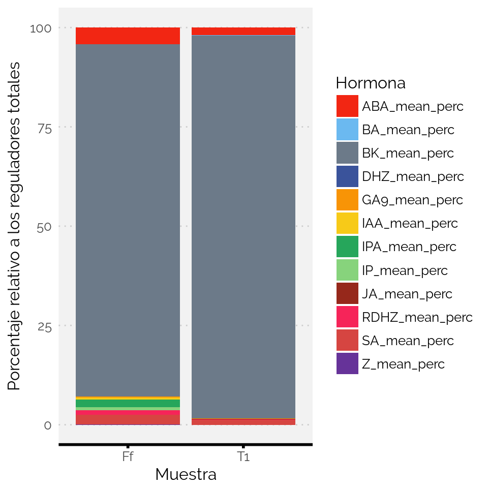

Como vemos, la concentración de `BK`, al ser tan grande nos enmascara el resto. Así pues vamos a repetir pero sin `BK`, para observar las variaciones en el resto de hormonas.

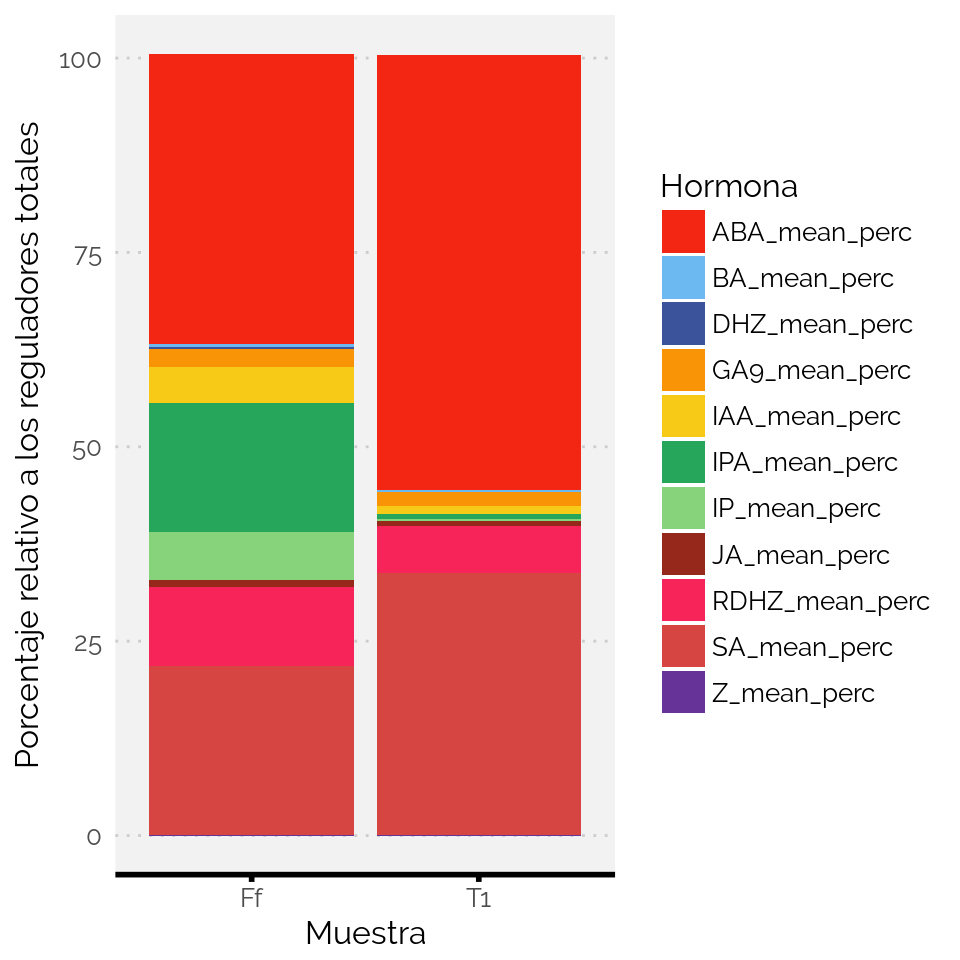

Aquí observamos lo visto anteriormente para `IAA`, `IP` e `IPA`, pero además observamos que pese a que el `ABA` no nos daba diferencias significativas, porcentualmente disminuye su concentración en las agallas. También observamos que son los ribósidos de CKs los que mayoritariamente incrementan porcentualmente su concentración.

## Ratios hormonales

Puede ser interesante, más que los valores individuales de cada hormona, los ratios entre diferentes grupos hormonales. Los ratios más importantes suelen ser entre auxinas y citoquininas por un lado y entre inhibidores (`ABA`, `JA`, `SA`) y citoquininas por otro.  
Vamos a crear los ratios y ver los resultados:

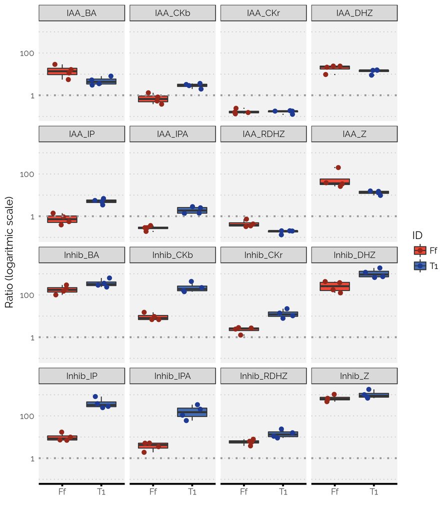

```r
# creamos los ratios
data_pgrs_conc_ratios <- data_pgrs_conc_or %>%
  mutate(IAA_IP = IAA / IP,
         IAA_IPA = IAA / IPA,
         IAA_DHZ = IAA / DHZ,
         IAA_RDHZ = IAA / RDHZ,
         IAA_Z = IAA / Z,
         IAA_BA = IAA / BA,
         IAA_CKb = IAA / (IP + DHZ + Z),
         IAA_CKr = IAA / (IPA + RDHZ),
         Inhib_IP = (ABA + JA + SA) / IP,
         Inhib_IPA = (ABA + JA + SA) / IPA,
         Inhib_DHZ = (ABA + JA + SA) / DHZ,
         Inhib_RDHZ = (ABA + JA + SA) / RDHZ,
         Inhib_Z = (ABA + JA + SA) / Z,
         Inhib_BA = (ABA + JA + SA) / BA,
         Inhib_CKb = (ABA + JA + SA) / (IP + DHZ + Z),
         Inhib_CKr = (ABA + JA + SA) / (IPA + RDHZ)) %>%
  select(ID, árbol, IAA_IP:Inhib_CKr)

# vemos la gráfica
data_pgrs_conc_ratios %>%
  gather(Regulador, Ratio, IAA_IP:Inhib_CKr) %>%
  ggplot(aes(x = ID, y = Ratio, fill = ID)) +
  geom_boxplot(outlier.size = 0) +
  geom_point(aes(colour = ID),
             position = position_jitter(width = .25, height = 0),
             shape = 19, size = 2) +
  geom_hline(yintercept = 1, size = 1, linetype = 'dotted',
             colour = 'grey60') +
  facet_wrap(~ Regulador) +
  labs(x = '', y = 'Ratio (logaritmic scale)') +
  scale_fill_manual(values = c('#EF4836', '#446CB3')) +
  scale_colour_manual(values = c('#96281B', '#1F3A93')) +
  scale_y_log10(limits = c(0.1, 2000)) +
  theme_bw() +
  theme(axis.ticks.x = element_line(size = 1, colour = 'black'),
        axis.line = element_line(size = 1, colour = "black"),
        axis.line.y = element_blank(),
        axis.ticks.y = element_blank(),
        panel.border = element_blank(),
        panel.grid.minor.y = element_line(size = .5, colour = 'grey80', linetype = 'dotted'),
        panel.grid.minor.x = element_blank(),
        panel.grid.major.y = element_line(size = .5, colour = 'grey80', linetype = 'dotted'),
        panel.grid.major.x = element_blank(),
        panel.background = element_rect(fill = 'grey95'),
        legend.background = element_blank(),
        legend.key = element_blank(),
        text = element_text(family = "Raleway", size = 12))
```

En los ratios vemos también cosas interesantes:

# Conclusiones preliminares

De momento esto es lo que se me ocurre para analizar con los datos disponibles. A mi me parece que puede tener entidad como para publicarlo solo (aunque quizás en revista de menor impacto), ya que los resultados dan juego a una buena discusión, además de que no hay muchos estudios como éste.

# Información de la sesión de R